# Index

Joshua Lansing

May 10, 2019

## Summary information

The data was provided by [Shooting Tracker](http://www.shootingtracker.com/). There were a total of 340 in 2018. 373 lives were lost that year. Chicago suffered the most casualties (injured and killed). California was the state that suffered the most casualties. And Massachusetts, Utah suffered the least amount of casualties.

## Summary Table

| state | Deaths | Injured |
| --- | --- | --- |
| California | 50 | 136 |
| Florida | 48 | 132 |
| Pennsylvania | 35 | 63 |
| Texas | 29 | 62 |
| Illinois | 21 | 150 |
| Tennessee | 19 | 68 |
| Louisiana | 15 | 50 |
| North Carolina | 14 | 37 |
| Ohio | 13 | 46 |
| Maryland | 13 | 31 |
| Alabama | 12 | 55 |
| Missouri | 12 | 52 |
| Michigan | 10 | 28 |
| Indiana | 10 | 27 |
| Colorado | 9 | 27 |
| Kentucky | 7 | 25 |
| Arkansas | 7 | 17 |
| New York | 5 | 53 |
| South Carolina | 5 | 19 |
| New Mexico | 5 | 4 |
| Delaware | 5 | 0 |
| New Jersey | 4 | 54 |
| Washington | 4 | 9 |
| Arizona | 4 | 5 |
| Georgia | 3 | 33 |
| Nevada | 3 | 15 |
| District of Columbia | 2 | 23 |
| Oklahoma | 2 | 19 |
| Virginia | 2 | 17 |
| Mississippi | 1 | 17 |
| Nebraska | 1 | 16 |
| Wisconsin | 1 | 16 |
| Minnesota | 1 | 14 |
| Kansas | 1 | 11 |
| Connecticut | 0 | 8 |
| Massachusetts | 0 | 4 |
| Utah | 0 | 4 |

By and large, we can see from this table, at least by state, the number of those injured is larger than those killed. In fact, only two states has a higher amount of people killed than injured. We can also see that the most casualties appear to happen in states with highest in states known for having higher populations (eg. California, Florida).

## Description of a particular incident

On November 7, 2018, a terrible shooting occurred at 99 Rolling Oaks Dr in southern California. According to [USA Today](https://www.usatoday.com/story/news/2018/11/08/mass-shooting-borderline-bar-grill-thousand-oaks-southern-california/1927840002/), 13 were killed, and 2 were injured. This totals to 15 casualties.

## Interactive map

This map is used to visually view the location of shootings, as well as their magnitude by number of casualties.

[interactive chart not shown]

Here we see that most of the shootings occur in the south-eastern parts of the US. We can also see the severity (number of casualties) appears to go up as the size of the cities goes up.

## Plot of Choice

I decided to ask myself “Were there months throughout 2018 that had more or less shooting casualties than others?”

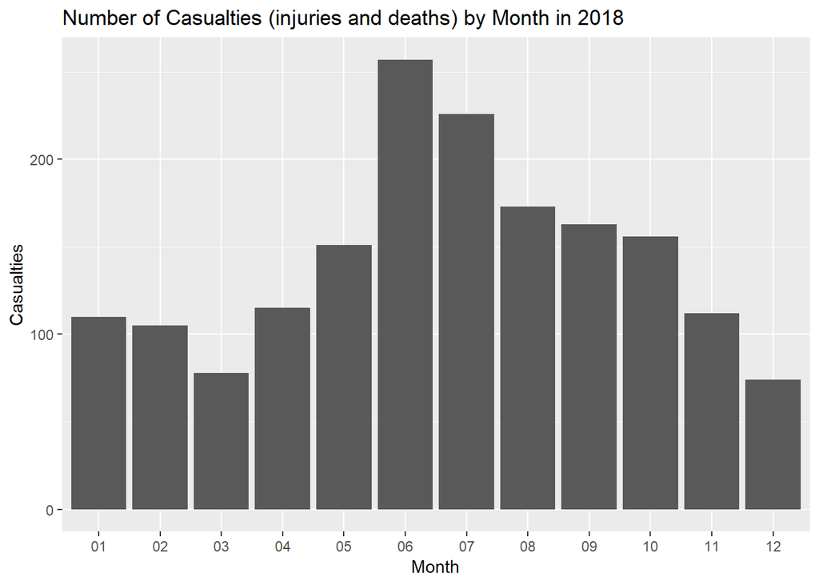

The chart shows that significantly more shootings happened in June and July than in other months. I also found it interesting that the least amount of shootings occurred in December. I can’t say much for sure, considering this is only showing shootings from 2018, but perhaps shooting rates change with travelling seasons. i.e: People usually travel more in the summer, and people are more likely to stay home, or travel differently for the holidays in the winter.